# Project: Investigating TMDB Dataset

- Introduction
- Data Wrangling
- Exploratory Data Analysis
- Conclusions

## Introduction

Attribute in the Dataset

1. id
2. imdb_id
3. popularity
4. budget
5. revenue
6. original_title
7. cast
8. homepage
9. director
10. tagline
11. keywords
12. overview
13. runtime
14. genres
15. production_companies
16. release_date
17. vote_count
18. vote_average
19. release_year
20. budget_adj
21. revenue_adj

### Dataset Description

```
The dataset that will be analyzed in this report is the TMDB movie data containing information   about 10,000 movies from The Movie Database (TMDB).
```

### Question(s) for Analysis

1. What is the relationship between popularity and rating of genres?
2. Which Genre is the highest Release profile?
3. Movies Budget Across the years?
4. Top Rated casts based on voting

```python
# important packages for nvestigating this dataset
#   plan to use.
import pandas as pd
import numpy as np
import matplotlib.pyplot as plt
import seaborn as sns
%matplotlib inline
```

### Importing necessary packages for investigating the data

## Data Wrangling

The second stage of the process is where we acquire the data listed in the project resources. Describe the methods used to acquire them and any problems encountered. We record problems you encountered and any resolutions achieved. Tis includes any data quality issues, and any resolution steps taken. This initial collection includes extraction details and source details, and subsequently loaded into Python and analysed in Jupyter notebook.

### General Properties

Reading the data from the csv file and Undersatnding the Dataset pattern

```python
# Load your data and print out a few lines. Perform operations to inspect data
df_tdm=pd.read_csv('tmdb-movies.csv')
df_tdm.head()
```

|  | id | imdb_id | popularity | budget | revenue | original_title | cast | homepage | director | tagline | ... | overview | runtime | genres | production_companies | release_date | vote_count | vote_average | release_year | budget_adj | revenue_adj |
| --- | --- | --- | --- | --- | --- | --- | --- | --- | --- | --- | --- | --- | --- | --- | --- | --- | --- | --- | --- | --- | --- |
| 0 | 135397 | tt0369610 | 32.985763 | 150000000 | 1513528810 | Jurassic World | Chris Pratt\|Bryce Dallas Howard\|Irrfan Khan\|Vi... | http://www.jurassicworld.com/ | Colin Trevorrow | The park is open. | ... | Twenty-two years after the events of Jurassic ... | 124 | Action\|Adventure\|Science Fiction\|Thriller | Universal Studios\|Amblin Entertainment\|Legenda... | 6/9/15 | 5562 | 6.5 | 2015 | 1.379999e+08 | 1.392446e+09 |
| 1 | 76341 | tt1392190 | 28.419936 | 150000000 | 378436354 | Mad Max: Fury Road | Tom Hardy\|Charlize Theron\|Hugh Keays-Byrne\|Nic... | http://www.madmaxmovie.com/ | George Miller | What a Lovely Day. | ... | An apocalyptic story set in the furthest reach... | 120 | Action\|Adventure\|Science Fiction\|Thriller | Village Roadshow Pictures\|Kennedy Miller Produ... | 5/13/15 | 6185 | 7.1 | 2015 | 1.379999e+08 | 3.481613e+08 |
| 2 | 262500 | tt2908446 | 13.112507 | 110000000 | 295238201 | Insurgent | Shailene Woodley\|Theo James\|Kate Winslet\|Ansel... | http://www.thedivergentseries.movie/#insurgent | Robert Schwentke | One Choice Can Destroy You | ... | Beatrice Prior must confront her inner demons ... | 119 | Adventure\|Science Fiction\|Thriller | Summit Entertainment\|Mandeville Films\|Red Wago... | 3/18/15 | 2480 | 6.3 | 2015 | 1.012000e+08 | 2.716190e+08 |
| 3 | 140607 | tt2488496 | 11.173104 | 200000000 | 2068178225 | Star Wars: The Force Awakens | Harrison Ford\|Mark Hamill\|Carrie Fisher\|Adam D... | http://www.starwars.com/films/star-wars-episod... | J.J. Abrams | Every generation has a story. | ... | Thirty years after defeating the Galactic Empi... | 136 | Action\|Adventure\|Science Fiction\|Fantasy | Lucasfilm\|Truenorth Productions\|Bad Robot | 12/15/15 | 5292 | 7.5 | 2015 | 1.839999e+08 | 1.902723e+09 |
| 4 | 168259 | tt2820852 | 9.335014 | 190000000 | 1506249360 | Furious 7 | Vin Diesel\|Paul Walker\|Jason Statham\|Michelle ... | http://www.furious7.com/ | James Wan | Vengeance Hits Home | ... | Deckard Shaw seeks revenge against Dominic Tor... | 137 | Action\|Crime\|Thriller | Universal Pictures\|Original Film\|Media Rights ... | 4/1/15 | 2947 | 7.3 | 2015 | 1.747999e+08 | 1.385749e+09 |

5 rows × 21 columns

```python
df_tdm.shape
```

```
(10866, 21)
```

```python
df_tdm.describe()
```

|  | id | popularity | budget | revenue | runtime | vote_count | vote_average | release_year | budget_adj | revenue_adj |
| --- | --- | --- | --- | --- | --- | --- | --- | --- | --- | --- |
| count | 10866.000000 | 10866.000000 | 1.086600e+04 | 1.086600e+04 | 10866.000000 | 10866.000000 | 10866.000000 | 10866.000000 | 1.086600e+04 | 1.086600e+04 |
| mean | 66064.177434 | 0.646441 | 1.462570e+07 | 3.982332e+07 | 102.070863 | 217.389748 | 5.974922 | 2001.322658 | 1.755104e+07 | 5.136436e+07 |
| std | 92130.136561 | 1.000185 | 3.091321e+07 | 1.170035e+08 | 31.381405 | 575.619058 | 0.935142 | 12.812941 | 3.430616e+07 | 1.446325e+08 |
| min | 5.000000 | 0.000065 | 0.000000e+00 | 0.000000e+00 | 0.000000 | 10.000000 | 1.500000 | 1960.000000 | 0.000000e+00 | 0.000000e+00 |
| 25% | 10596.250000 | 0.207583 | 0.000000e+00 | 0.000000e+00 | 90.000000 | 17.000000 | 5.400000 | 1995.000000 | 0.000000e+00 | 0.000000e+00 |
| 50% | 20669.000000 | 0.383856 | 0.000000e+00 | 0.000000e+00 | 99.000000 | 38.000000 | 6.000000 | 2006.000000 | 0.000000e+00 | 0.000000e+00 |
| 75% | 75610.000000 | 0.713817 | 1.500000e+07 | 2.400000e+07 | 111.000000 | 145.750000 | 6.600000 | 2011.000000 | 2.085325e+07 | 3.369710e+07 |
| max | 417859.000000 | 32.985763 | 4.250000e+08 | 2.781506e+09 | 900.000000 | 9767.000000 | 9.200000 | 2015.000000 | 4.250000e+08 | 2.827124e+09 |

```python
df_tdm.info();
```

```
<class 'pandas.core.frame.DataFrame'>
RangeIndex: 10866 entries, 0 to 10865
Data columns (total 21 columns):
 #   Column                Non-Null Count  Dtype
---  ------                --------------  -----
 0   id                    10866 non-null  int64
 1   imdb_id               10856 non-null  object
 2   popularity            10866 non-null  float64
 3   budget                10866 non-null  int64
 4   revenue               10866 non-null  int64
 5   original_title        10866 non-null  object
 6   cast                  10790 non-null  object
 7   homepage              2936 non-null   object
 8   director              10822 non-null  object
 9   tagline               8042 non-null   object
 10  keywords              9373 non-null   object
 11  overview              10862 non-null  object
 12  runtime               10866 non-null  int64
 13  genres                10843 non-null  object
 14  production_companies  9836 non-null   object
 15  release_date          10866 non-null  object
 16  vote_count            10866 non-null  int64
 17  vote_average          10866 non-null  float64
 18  release_year          10866 non-null  int64
 19  budget_adj            10866 non-null  float64
 20  revenue_adj           10866 non-null  float64
dtypes: float64(4), int64(6), object(11)
memory usage: 1.7+ MB
```

```python
df_tdm.nunique()
```

```
id                      10865
imdb_id                 10855
popularity              10814
budget                    557
revenue                  4702
original_title          10571
cast                    10719
homepage                 2896
director                 5067
tagline                  7997
keywords                 8804
overview                10847
runtime                   247
genres                   2039
production_companies     7445
release_date             5909
vote_count               1289
vote_average               72
release_year               56
budget_adj               2614
revenue_adj              4840
dtype: int64
```

```python
df_tdm.dtypes
```

```
id                        int64
imdb_id                  object
popularity              float64
budget                    int64
revenue                   int64
original_title           object
cast                     object
homepage                 object
director                 object
tagline                  object
keywords                 object
overview                 object
runtime                   int64
genres                   object
production_companies     object
release_date             object
vote_count                int64
vote_average            float64
release_year              int64
budget_adj              float64
revenue_adj             float64
dtype: object
```

1. We can now see that there are 10866 entries 21 columns
2. Some of columns contain a few missing values such as cast ,director,tagline and keywords..
3. some Columns are irrelevant for our investigation like imdb_id, homepage, tagline, overviewlook so we should drop them

### Data Cleaning

> **Tip**: Make sure that you keep your reader informed on the steps that you are taking in your investigation. Follow every code cell, or every set of related code cells, with a markdown cell to describe to the reader what was found in the preceding cell(s). Try to make it so that the reader can then understand what they will be seeing in the following cell(s).

```python
# check the duplicated row
df_tdm.duplicated().sum()
```

```
1
```

```python
# Drop the duplicated row and check if there are no duplicated rows after cleaning
df_tdm.drop_duplicates(inplace=True)
df_tdm.duplicated().sum()
```

```
0
```

```python
# After discussing the structure of the data and any problems that need to be
#   cleaned, perform those cleaning steps in the second part of this section.
df_tdm.drop(['homepage','tagline','keywords','overview','imdb_id'], axis=1, inplace=True)
df_tdm.head(10)
```

|  | id | popularity | budget | revenue | original_title | cast | director | runtime | genres | production_companies | release_date | vote_count | vote_average | release_year | budget_adj | revenue_adj |
| --- | --- | --- | --- | --- | --- | --- | --- | --- | --- | --- | --- | --- | --- | --- | --- | --- |
| 0 | 135397 | 32.985763 | 150000000 | 1513528810 | Jurassic World | Chris Pratt\|Bryce Dallas Howard\|Irrfan Khan\|Vi... | Colin Trevorrow | 124 | Action\|Adventure\|Science Fiction\|Thriller | Universal Studios\|Amblin Entertainment\|Legenda... | 6/9/15 | 5562 | 6.5 | 2015 | 1.379999e+08 | 1.392446e+09 |
| 1 | 76341 | 28.419936 | 150000000 | 378436354 | Mad Max: Fury Road | Tom Hardy\|Charlize Theron\|Hugh Keays-Byrne\|Nic... | George Miller | 120 | Action\|Adventure\|Science Fiction\|Thriller | Village Roadshow Pictures\|Kennedy Miller Produ... | 5/13/15 | 6185 | 7.1 | 2015 | 1.379999e+08 | 3.481613e+08 |
| 2 | 262500 | 13.112507 | 110000000 | 295238201 | Insurgent | Shailene Woodley\|Theo James\|Kate Winslet\|Ansel... | Robert Schwentke | 119 | Adventure\|Science Fiction\|Thriller | Summit Entertainment\|Mandeville Films\|Red Wago... | 3/18/15 | 2480 | 6.3 | 2015 | 1.012000e+08 | 2.716190e+08 |
| 3 | 140607 | 11.173104 | 200000000 | 2068178225 | Star Wars: The Force Awakens | Harrison Ford\|Mark Hamill\|Carrie Fisher\|Adam D... | J.J. Abrams | 136 | Action\|Adventure\|Science Fiction\|Fantasy | Lucasfilm\|Truenorth Productions\|Bad Robot | 12/15/15 | 5292 | 7.5 | 2015 | 1.839999e+08 | 1.902723e+09 |
| 4 | 168259 | 9.335014 | 190000000 | 1506249360 | Furious 7 | Vin Diesel\|Paul Walker\|Jason Statham\|Michelle ... | James Wan | 137 | Action\|Crime\|Thriller | Universal Pictures\|Original Film\|Media Rights ... | 4/1/15 | 2947 | 7.3 | 2015 | 1.747999e+08 | 1.385749e+09 |
| 5 | 281957 | 9.110700 | 135000000 | 532950503 | The Revenant | Leonardo DiCaprio\|Tom Hardy\|Will Poulter\|Domhn... | Alejandro González Iñárritu | 156 | Western\|Drama\|Adventure\|Thriller | Regency Enterprises\|Appian Way\|CatchPlay\|Anony... | 12/25/15 | 3929 | 7.2 | 2015 | 1.241999e+08 | 4.903142e+08 |
| 6 | 87101 | 8.654359 | 155000000 | 440603537 | Terminator Genisys | Arnold Schwarzenegger\|Jason Clarke\|Emilia Clar... | Alan Taylor | 125 | Science Fiction\|Action\|Thriller\|Adventure | Paramount Pictures\|Skydance Productions | 6/23/15 | 2598 | 5.8 | 2015 | 1.425999e+08 | 4.053551e+08 |
| 7 | 286217 | 7.667400 | 108000000 | 595380321 | The Martian | Matt Damon\|Jessica Chastain\|Kristen Wiig\|Jeff ... | Ridley Scott | 141 | Drama\|Adventure\|Science Fiction | Twentieth Century Fox Film Corporation\|Scott F... | 9/30/15 | 4572 | 7.6 | 2015 | 9.935996e+07 | 5.477497e+08 |
| 8 | 211672 | 7.404165 | 74000000 | 1156730962 | Minions | Sandra Bullock\|Jon Hamm\|Michael Keaton\|Allison... | Kyle Balda\|Pierre Coffin | 91 | Family\|Animation\|Adventure\|Comedy | Universal Pictures\|Illumination Entertainment | 6/17/15 | 2893 | 6.5 | 2015 | 6.807997e+07 | 1.064192e+09 |
| 9 | 150540 | 6.326804 | 175000000 | 853708609 | Inside Out | Amy Poehler\|Phyllis Smith\|Richard Kind\|Bill Ha... | Pete Docter | 94 | Comedy\|Animation\|Family | Walt Disney Pictures\|Pixar Animation Studios\|W... | 6/9/15 | 3935 | 8.0 | 2015 | 1.609999e+08 | 7.854116e+08 |

```python
print(df_tdm['budget_adj'].mean())
```

```
17551039.82288678
```

```python
# Replace 0 values with mean.
df_tdm['budget_adj'] = df_tdm['budget_adj'].replace(0, 17551039.822886847)
```

```python
# Get average of runtime
print(df_tdm['runtime'].mean())
```

```
102.07086324314375
```

```python
# Replace 0 values with mean
df_tdm['runtime'] = df_tdm['runtime'].replace(0, 102.07086324314375)
df_tdm.describe()
```

|  | id | popularity | budget | revenue | runtime | vote_count | vote_average | release_year | budget_adj | revenue_adj |
| --- | --- | --- | --- | --- | --- | --- | --- | --- | --- | --- |
| count | 10866.000000 | 10866.000000 | 1.086600e+04 | 1.086600e+04 | 10866.000000 | 10866.000000 | 10866.000000 | 10866.000000 | 1.086600e+04 | 1.086600e+04 |
| mean | 66064.177434 | 0.646441 | 1.462570e+07 | 3.982332e+07 | 102.362065 | 217.389748 | 5.974922 | 2001.322658 | 2.675136e+07 | 5.136436e+07 |
| std | 92130.136561 | 1.000185 | 3.091321e+07 | 1.170035e+08 | 30.902781 | 575.619058 | 0.935142 | 12.812941 | 3.050850e+07 | 1.446325e+08 |
| min | 5.000000 | 0.000065 | 0.000000e+00 | 0.000000e+00 | 2.000000 | 10.000000 | 1.500000 | 1960.000000 | 9.210911e-01 | 0.000000e+00 |
| 25% | 10596.250000 | 0.207583 | 0.000000e+00 | 0.000000e+00 | 90.000000 | 17.000000 | 5.400000 | 1995.000000 | 1.755104e+07 | 0.000000e+00 |
| 50% | 20669.000000 | 0.383856 | 0.000000e+00 | 0.000000e+00 | 99.000000 | 38.000000 | 6.000000 | 2006.000000 | 1.755104e+07 | 0.000000e+00 |
| 75% | 75610.000000 | 0.713817 | 1.500000e+07 | 2.400000e+07 | 111.000000 | 145.750000 | 6.600000 | 2011.000000 | 2.085325e+07 | 3.369710e+07 |
| max | 417859.000000 | 32.985763 | 4.250000e+08 | 2.781506e+09 | 900.000000 | 9767.000000 | 9.200000 | 2015.000000 | 4.250000e+08 | 2.827124e+09 |

```python
df_tdm.shape
```

```
(10866, 16)
```

We remove irrelevant rows we decrease the row to 16 from 21 rows

### Data cleaning - Changing Datatypes

Change datatypes of columns to appropriate kinds. Ex. 'release_date' needs to be datetime.

```python
df_tdm['release_date'] =  pd.to_datetime(df_tdm['release_date'])

df_tdm.dtypes
```

```
id                               int64
popularity                     float64
budget                           int64
revenue                          int64
original_title                  object
cast                            object
director                        object
runtime                        float64
genres                          object
production_companies            object
release_date            datetime64[ns]
vote_count                       int64
vote_average                   float64
release_year                     int64
budget_adj                     float64
revenue_adj                    float64
dtype: object
```

```python
# Show the basic information of cleaned data
df_tdm.info()
```

```
<class 'pandas.core.frame.DataFrame'>
RangeIndex: 10866 entries, 0 to 10865
Data columns (total 16 columns):
 #   Column                Non-Null Count  Dtype
---  ------                --------------  -----
 0   id                    10866 non-null  int64
 1   popularity            10866 non-null  float64
 2   budget                10866 non-null  int64
 3   revenue               10866 non-null  int64
 4   original_title        10866 non-null  object
 5   cast                  10790 non-null  object
 6   director              10822 non-null  object
 7   runtime               10866 non-null  float64
 8   genres                10843 non-null  object
 9   production_companies  9836 non-null   object
 10  release_date          10866 non-null  datetime64[ns]
 11  vote_count            10866 non-null  int64
 12  vote_average          10866 non-null  float64
 13  release_year          10866 non-null  int64
 14  budget_adj            10866 non-null  float64
 15  revenue_adj           10866 non-null  float64
dtypes: datetime64[ns](1), float64(5), int64(5), object(5)
memory usage: 1.3+ MB
```

Some of the columns contain multiple entries delimitted by ‘|’. Use split function to seperate the rows

```python
# split the genre column
df_tdm['genres']=df_tdm['genres'].str.split("|")
df_tdm=df_tdm.explode("genres",ignore_index =True)
df_tdm.head()
```

|  | id | popularity | budget | revenue | original_title | cast | director | runtime | genres | production_companies | release_date | vote_count | vote_average | release_year | budget_adj | revenue_adj |
| --- | --- | --- | --- | --- | --- | --- | --- | --- | --- | --- | --- | --- | --- | --- | --- | --- |
| 0 | 135397 | 32.985763 | 150000000 | 1513528810 | Jurassic World | Chris Pratt\|Bryce Dallas Howard\|Irrfan Khan\|Vi... | Colin Trevorrow | 124.0 | Action | Universal Studios\|Amblin Entertainment\|Legenda... | 2015-06-09 | 5562 | 6.5 | 2015 | 1.379999e+08 | 1.392446e+09 |
| 1 | 135397 | 32.985763 | 150000000 | 1513528810 | Jurassic World | Chris Pratt\|Bryce Dallas Howard\|Irrfan Khan\|Vi... | Colin Trevorrow | 124.0 | Adventure | Universal Studios\|Amblin Entertainment\|Legenda... | 2015-06-09 | 5562 | 6.5 | 2015 | 1.379999e+08 | 1.392446e+09 |
| 2 | 135397 | 32.985763 | 150000000 | 1513528810 | Jurassic World | Chris Pratt\|Bryce Dallas Howard\|Irrfan Khan\|Vi... | Colin Trevorrow | 124.0 | Science Fiction | Universal Studios\|Amblin Entertainment\|Legenda... | 2015-06-09 | 5562 | 6.5 | 2015 | 1.379999e+08 | 1.392446e+09 |
| 3 | 135397 | 32.985763 | 150000000 | 1513528810 | Jurassic World | Chris Pratt\|Bryce Dallas Howard\|Irrfan Khan\|Vi... | Colin Trevorrow | 124.0 | Thriller | Universal Studios\|Amblin Entertainment\|Legenda... | 2015-06-09 | 5562 | 6.5 | 2015 | 1.379999e+08 | 1.392446e+09 |
| 4 | 76341 | 28.419936 | 150000000 | 378436354 | Mad Max: Fury Road | Tom Hardy\|Charlize Theron\|Hugh Keays-Byrne\|Nic... | George Miller | 120.0 | Action | Village Roadshow Pictures\|Kennedy Miller Produ... | 2015-05-13 | 6185 | 7.1 | 2015 | 1.379999e+08 | 3.481613e+08 |

```python
# checking theunique values
df_tdm.genres.unique()
```

```
array(['Action', 'Adventure', 'Science Fiction', 'Thriller', 'Fantasy',
       'Crime', 'Western', 'Drama', 'Family', 'Animation', 'Comedy',
       'Mystery', 'Romance', 'War', 'History', 'Music', 'Horror',
       'Documentary', 'TV Movie', nan, 'Foreign'], dtype=object)
```

## Exploratory Data Analysis

> **Tip**: Now that you've trimmed and cleaned your data, you're ready to move on to exploration. **Compute statistics** and **create visualizations** with the goal of addressing the research questions that you posed in the Introduction section. You should compute the relevant statistics throughout the analysis when an inference is made about the data. Note that at least two or more kinds of plots should be created as part of the exploration, and you must compare and show trends in the varied visualizations.

> **Tip**: - Investigate the stated question(s) from multiple angles. It is recommended that you be systematic with your approach. Look at one variable at a time, and then follow it up by looking at relationships between variables. You should explore at least three variables in relation to the primary question. This can be an exploratory relationship between three variables of interest, or looking at how two independent variables relate to a single dependent variable of interest. Lastly, you should perform both single-variable (1d) and multiple-variable (2d) explorations.

### Looking the current dataset status in vizualization using histogram

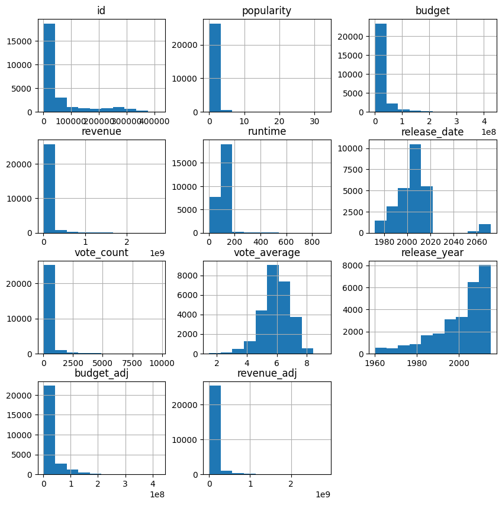

```python
# Explore what the histogram of the data looks like
df_tdm.hist(figsize=(10,10));
```

Some of the attributes are skewed so we can explore more to get the interesing facts

### Question 1 which genre are popular and rating?

```python
# Find the total count for each genre
df_tdm.groupby(['genres']).count()['id'].sort_values(ascending=False)
```

```
genres
Drama              4761
Comedy             3793
Thriller           2908
Action             2385
Romance            1712
Horror             1637
Adventure          1471
Crime              1355
Family             1231
Science Fiction    1230
Fantasy             916
Mystery             810
Animation           699
Documentary         520
Music               408
History             334
War                 270
Foreign             188
TV Movie            167
Western             165
Name: id, dtype: int64
```

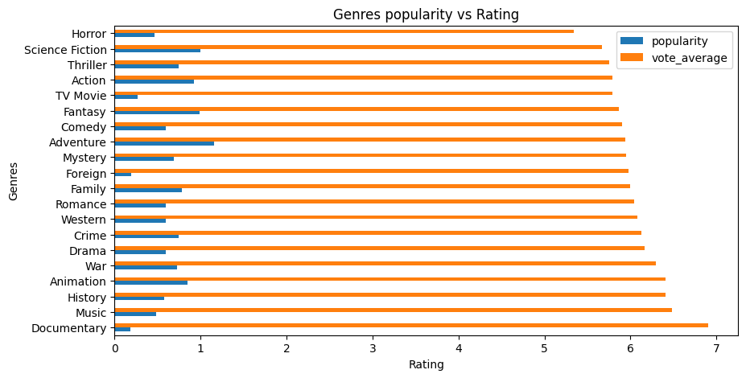

```python
fig,ax=plt.subplots(figsize=(10, 5))
df_popularity=df_tdm[['genres', 'popularity', 'vote_average']].groupby(['genres']).mean().sort_values(["vote_average"], ascending=False)
df_popularity.plot.barh(ax=ax);
plt.ylabel('Genres')
plt.xlabel('Rating')
plt.title('Genres popularity vs Rating');
```

### Questions 2 which Genre has the highest Release profile?

```python
df_mov=df_tdm.groupby(['genres']).count()['id'].sort_values(ascending=False)
df_mov
```

```
genres
Drama              4761
Comedy             3793
Thriller           2908
Action             2385
Romance            1712
Horror             1637
Adventure          1471
Crime              1355
Family             1231
Science Fiction    1230
Fantasy             916
Mystery             810
Animation           699
Documentary         520
Music               408
History             334
War                 270
Foreign             188
TV Movie            167
Western             165
Name: id, dtype: int64
```

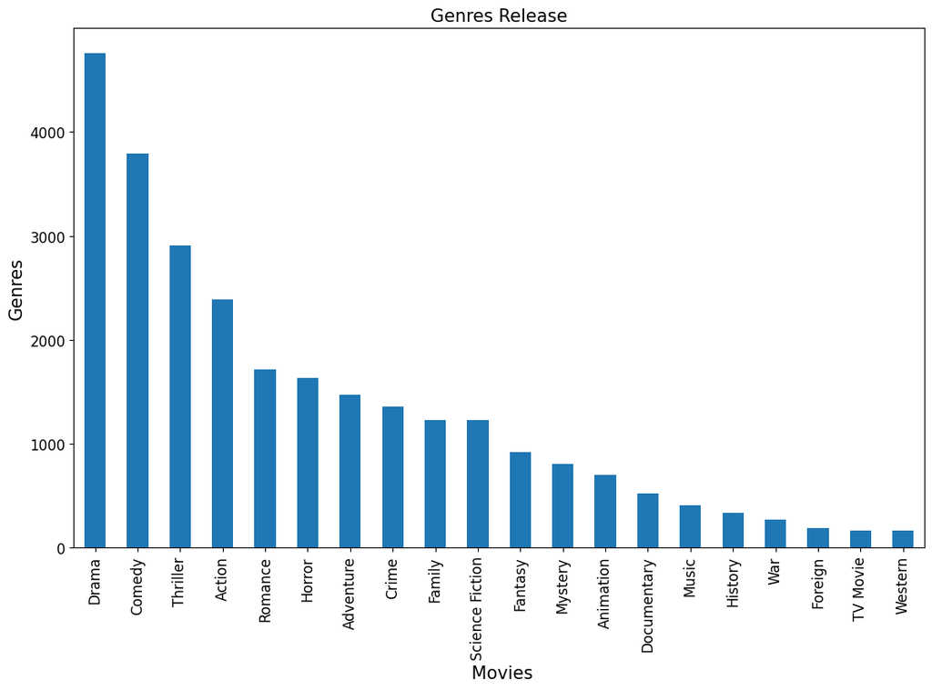

```python
#plot a 'bar' plot using plot function for 'genre vs number of movies'.
df_mov.plot(kind= 'bar',figsize = (13,8),fontsize=12)
#setup the title and the labels of the plot.
plt.title("Genres Release",fontsize=15)
plt.xlabel(' Movies',fontsize=15)
plt.ylabel("Genres",fontsize= 15)
```

### In the given movie data set Drama is the most released genres in the entire given time so thr drama genre tend to be the most rleased genre in the other side western genre is the least released its interesting that this exploratory analysis gives us clue and make curisoty why is drama released in this amount and western genres cant able to do that.

### Question 3 Budget of movies across a years?

```python
df_high_realease = df_tdm.groupby('release_year').count()['budget'].sort_values(ascending=False)
df_high_realease.head()
```

```
release_year
2014    1471
2015    1388
2013    1386
2009    1360
2012    1279
Name: budget, dtype: int64
```

```python
df_tdm.budget.head(10)
```

```
0    150000000
1    150000000
2    150000000
3    150000000
4    150000000
5    150000000
6    150000000
7    150000000
8    110000000
9    110000000
Name: budget, dtype: int64
```

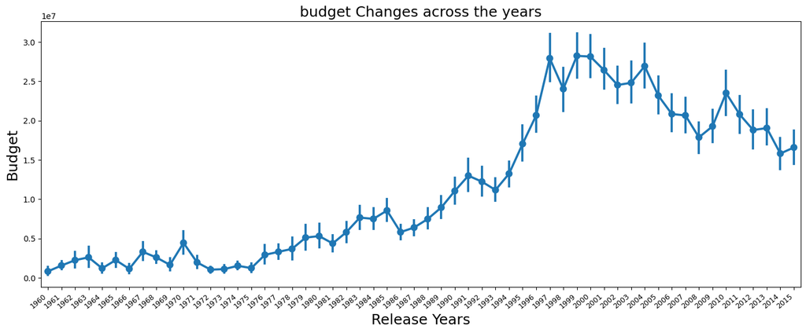

```python
plt.figure(figsize = (17,6))
ag=sns.pointplot(x="release_year", y="budget", data=df_tdm);
#Rotate xtick labels
ag.set_xticklabels(ag.get_xticklabels(), rotation = 40,ha='right', fontsize = 9);
#Give labels to axis
plt.xlabel('Release Years',fontsize = 18);
plt.ylabel('Budget',fontsize = 18);
plt.title('budget Changes across the years',fontsize = 18);
```

### 2.Around 1994 The budget started to increase exponentially based on the insight given by the graph

### Question 4: Top rated casts based on voting

```python
# split the cast column
df_tdm['cast']=df_tdm['cast'].str.split("|")
df_tdm=df_tdm.explode("cast",ignore_index =True)
df_tdm.head()
```

|  | id | popularity | budget | revenue | original_title | cast | director | runtime | genres | production_companies | release_date | vote_count | vote_average | release_year | budget_adj | revenue_adj |
| --- | --- | --- | --- | --- | --- | --- | --- | --- | --- | --- | --- | --- | --- | --- | --- | --- |
| 0 | 135397 | 32.985763 | 150000000 | 1513528810 | Jurassic World | Chris Pratt | Colin Trevorrow | 124.0 | Action | Universal Studios\|Amblin Entertainment\|Legenda... | 2015-06-09 | 5562 | 6.5 | 2015 | 1.379999e+08 | 1.392446e+09 |
| 1 | 135397 | 32.985763 | 150000000 | 1513528810 | Jurassic World | Bryce Dallas Howard | Colin Trevorrow | 124.0 | Action | Universal Studios\|Amblin Entertainment\|Legenda... | 2015-06-09 | 5562 | 6.5 | 2015 | 1.379999e+08 | 1.392446e+09 |
| 2 | 135397 | 32.985763 | 150000000 | 1513528810 | Jurassic World | Irrfan Khan | Colin Trevorrow | 124.0 | Action | Universal Studios\|Amblin Entertainment\|Legenda... | 2015-06-09 | 5562 | 6.5 | 2015 | 1.379999e+08 | 1.392446e+09 |
| 3 | 135397 | 32.985763 | 150000000 | 1513528810 | Jurassic World | Vincent D'Onofrio | Colin Trevorrow | 124.0 | Action | Universal Studios\|Amblin Entertainment\|Legenda... | 2015-06-09 | 5562 | 6.5 | 2015 | 1.379999e+08 | 1.392446e+09 |
| 4 | 135397 | 32.985763 | 150000000 | 1513528810 | Jurassic World | Nick Robinson | Colin Trevorrow | 124.0 | Action | Universal Studios\|Amblin Entertainment\|Legenda... | 2015-06-09 | 5562 | 6.5 | 2015 | 1.379999e+08 | 1.392446e+09 |

```python
df_best_cast = df_tdm.groupby('cast').count()['vote_average'].sort_values(ascending=False)
df_top_casts=pd.DataFrame(df_best_cast.head(10))
df_top_casts
```

| cast | vote_average |
| --- | --- |
| Samuel L. Jackson | 209 |
| Bruce Willis | 188 |
| Nicolas Cage | 184 |
| Robert De Niro | 176 |
| Michael Caine | 147 |
| Clint Eastwood | 139 |
| Liam Neeson | 139 |
| Eddie Murphy | 136 |
| Robin Williams | 135 |
| Antonio Banderas | 133 |

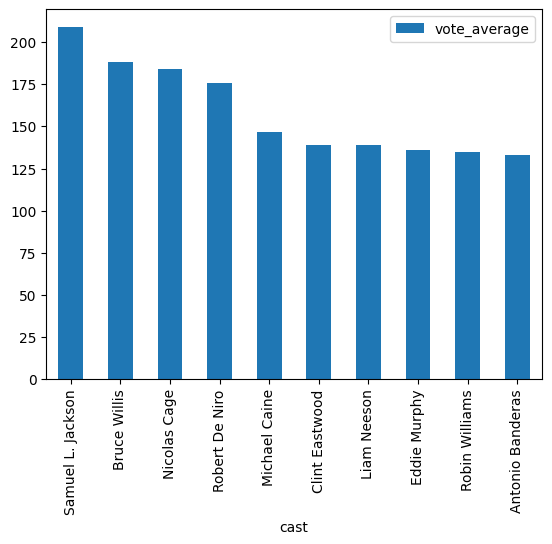

```python
ax = df_top_casts.plot.bar(stacked=True)
```

## Conclusions

> **Limitation**:A few notes about my data cleaning are that in the runtime and budget_adj I filled all of the 0 values with their means. This possibly could've been more accurate if I used regression to find like-properties to fill the 0 values instead

of the mean. We can do additional research on Tagline & overview of movies to understand how movies emotion changes according to genres. Data doesn't contain any information such as Age Range and Sex Variants